# On going IBM

## Leitura e Pre-processamento dos Dados (IBM_data.csv)

```r
dt.intra <- read.csv(
  "IBM_data.csv",
  header           = TRUE,
  stringsAsFactors = FALSE,
  sep              = ",",
  dec              = "."
)

dt.intra$Period <- mdy_hm(paste(dt.intra$Date, dt.intra$Time))

dt1 <- as_tibble(dt.intra) %>%
  arrange(Period) %>%
  filter(!(hour(Period) == 9 & minute(Period) < 40)) %>%
  filter(hour(Period) < 16) %>%
  filter(!(hour(Period) == 15 & minute(Period) >= 56)) %>%
  group_by(date(Period)) %>%
  filter(n() > 100) %>%
  ungroup() %>%
  arrange(Period) %>%
  mutate(
    Ret.1min   = (Close - lag(Close)) / lag(Close),
    Close.1min = Close
  ) %>%
  filter(!is.na(Ret.1min))

ret_sd       <- sd(dt1$Ret.1min, na.rm = TRUE)
ret_mean     <- mean(dt1$Ret.1min, na.rm = TRUE)
outlier_mask <- abs(dt1$Ret.1min - ret_mean) > 10 * ret_sd
dt1$Ret.1min[outlier_mask] <- NA
dt1$Ret.1min <- zoo::na.locf(dt1$Ret.1min, na.rm = FALSE)

ret.1min <- as.xts(dt1$Ret.1min, order.by = dt1$Period)

cat("Total de observacoes apos limpeza:", nrow(dt1), "\n")
```

```
Total de observacoes apos limpeza: 2644941
```

```r
cat("Periodo:", format(min(dt1$Period)), "a", format(max(dt1$Period)), "\n")
```

```
Periodo: 1998-01-02 09:41:00 a 2026-02-20 15:55:00
```

## Observacao Inicial

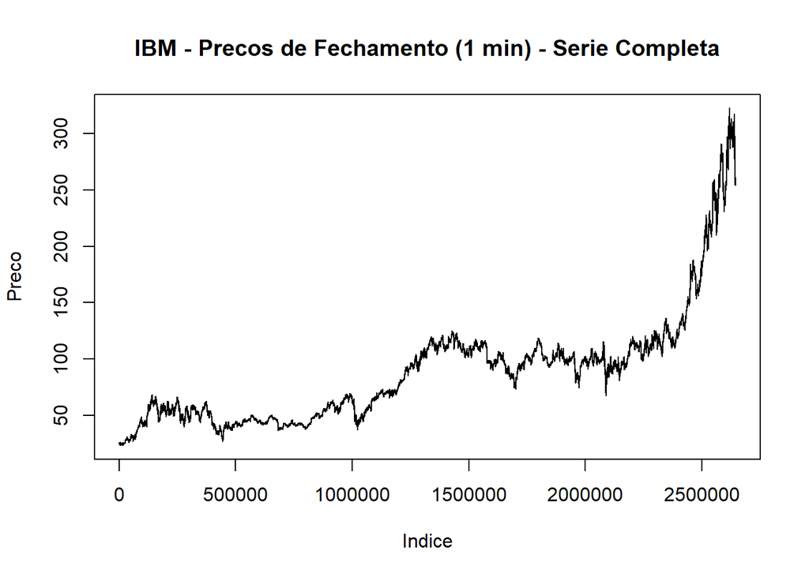

```r
plot(dt1$Close.1min,
     main = "IBM - Precos de Fechamento (1 min) - Serie Completa",
     col  = "black", type = "l",
     xlab = "Indice", ylab = "Preco")
```

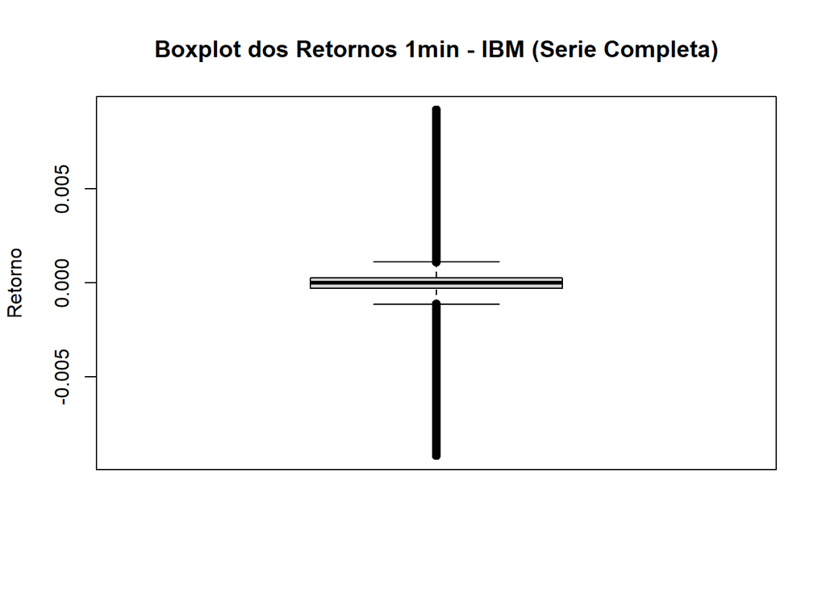

```r
boxplot(as.double(ret.1min),
        main = "Boxplot dos Retornos 1min - IBM (Serie Completa)",
        ylab = "Retorno")
```

## Preparacao da Serie Diaria de Retornos

```r
PRE_DAYS  <- 60   # dias de pregao antes do breakpoint
POST_DAYS <- 60   # dias de pregao depois do breakpoint

n_total   <- nrow(dt1)
rets_full <- dt1$Ret.1min


daily_close <- dt1 %>%
  mutate(trade_date = as.Date(Period)) %>%
  group_by(trade_date) %>%
  summarise(close_last = last(Close.1min), .groups = "drop") %>%
  arrange(trade_date) %>%
  mutate(
    close_prev = lag(close_last),
    close_diff = close_last - close_prev,
    close_pct  = abs(close_diff / close_prev)
  )

dt1_indexed <- dt1 %>%
  mutate(global_idx = row_number(), trade_date = as.Date(Period))

last_idx_per_day <- dt1_indexed %>%
  group_by(trade_date) %>%
  summarise(last_global_idx = max(global_idx), .groups = "drop")

daily_close <- daily_close %>%
  left_join(last_idx_per_day, by = "trade_date")

dc_clean <- daily_close %>%
  filter(!is.na(close_diff), !is.na(last_global_idx)) %>%
  mutate(
    close_prev2 = close_last - close_diff,
    daily_ret   = ifelse(close_prev2 > 0, close_diff / close_prev2, NA_real_)
  ) %>%
  filter(!is.na(daily_ret))

ret_daily <- dc_clean$daily_ret
n_daily   <- length(ret_daily)
log_price <- log(dc_clean$close_last)

cat(sprintf("Serie diaria: %d obs  |  %s  a  %s\n",
            n_daily,
            format(min(dc_clean$trade_date)),
            format(max(dc_clean$trade_date))))
```

```
Serie diaria: 7076 obs  |  1998-01-05  a  2026-02-20
```

```r
# ---- janela segura (opera em indices diarios) ----
safe_window_d <- function(start, end, n_max) {
  s <- max(1L, as.integer(start))
  e <- min(n_max, as.integer(end))
  if (s > e) return(NULL)
  s:e
}
```

> **Bai-Perron (1998, 2003) — Multiplas Quebras na Media**

> Generaliza o Teste de Chow para **m quebras simultaneas desconhecidas**. O modelo linear com $m$ quebras e:
> $$y_t = \mathbf{x}_t' \boldsymbol{\beta}_j + \varepsilon_t, \quad t = T_{j-1}+1, \ldots, T_j, \quad j = 1,\ldots,m+1$$
> onde os pontos $T_1 < T_2 < \cdots < T_m$ sao **estimados conjuntamente** por:
> $$\{\hat{T}_1, \ldots, \hat{T}_m\} = \arg\min_{T_1,\ldots,T_m} \sum_{j=1}^{m+1} \sum_{t=T_{j-1}+1}^{T_j} (y_t - \bar{y}_j)^2$$

> O numero otimo de quebras $m^*$ e selecionado pelo criterio BIC ou pelo teste sequencial de Bai-Perron, que controla a probabilidade de detectar quebras espurias. A busca e feita por programacao dinamica em $O(n^2)$.

> **Entrada:** $\log(r_t^2)$ (log do quadrado dos retornos diarios), que aproxima a serie a uma distribuicao normal e e estacionario, tornando o procedimento valido. A transformacao $\log(r_t^2) = \log(\sigma_t^2) + \log(z_t^2)$ lineariza a volatilidade, com o segundo termo atuando como ruido quasi-gaussiano de media conhecida.

```r
bp_override <- data.frame(
  h          = c("h = 0.05", "h = 0.05", "h = 0.05"),
  rank       = c(1L, 2L, 3L),
  trade_date = c("2007-10-15", "2009-06-03", "2018-09-28"),
  log_r2     = c(-17.2661, -9.3474, -11.8943),
  daily_ret  = c(917935, 1071588, 1950768)
)
# ^^^^^^^^ Para usar o modelo ao invés desses dados, mude para: bp_override <- NULL

# Transformacao: log(r_t^2) aproxima a distribuicao a normal e lineariza a estrutura de volatilidade.
log_ret2 <- log(ret_daily^2 + 1e-10)   # pequeno offset para evitar log(0)

run_bp <- function(series, h_val, max_breaks = 3) {
  fit    <- strucchange::breakpoints(series ~ 1, breaks = max_breaks, h = h_val)
  bp_idx <- fit$breakpoints
  bp_idx <- bp_idx[!is.na(bp_idx)]
  list(fit = fit, bp_idx = bp_idx, h = h_val)
}

if (is.null(bp_override)) {
  # ---- Roda o modelo normalmente ----
  bp_h05 <- run_bp(log_ret2, h_val = 0.05)
  bp_daily_idx <- bp_h05$bp_idx

  make_bp_summary <- function(bp_obj, label) {
    idx <- bp_obj$bp_idx
    if (length(idx) == 0) return(data.frame())
    data.frame(
      h          = label,
      rank       = seq_along(idx),
      trade_date = as.character(dc_clean$trade_date[idx]),
      log_r2     = round(log_ret2[idx], 4),
      daily_ret  = round(ret_daily[idx] * 100, 4)
    )
  }

  bp_all_summary <- make_bp_summary(bp_h05, "h = 0.05")

} else {
  # ---- Usa os dados do override ----
  bp_all_summary <- bp_override

  # Reconstroi bp_daily_idx a partir das datas do override para os chunks seguintes
  override_dates <- as.Date(bp_override$trade_date[bp_override$h == "h = 0.05"])
  bp_daily_idx   <- which(dc_clean$trade_date %in% override_dates)
}

cat("Bai-Perron — quebras na media de log(r_t^2)\n")
```

```
Bai-Perron — quebras na media de log(r_t^2)
```

```r
knitr::kable(bp_all_summary,
             col.names = c("h", "Rank", "Data", "log(r_t^2)", "Ret diario (%)"),
             caption   = "Bai-Perron: quebras estruturais em log(r_t^2) — serie diaria")
```

Bai-Perron: quebras estruturais em log(r_t^2) — serie diaria

[output not shown]

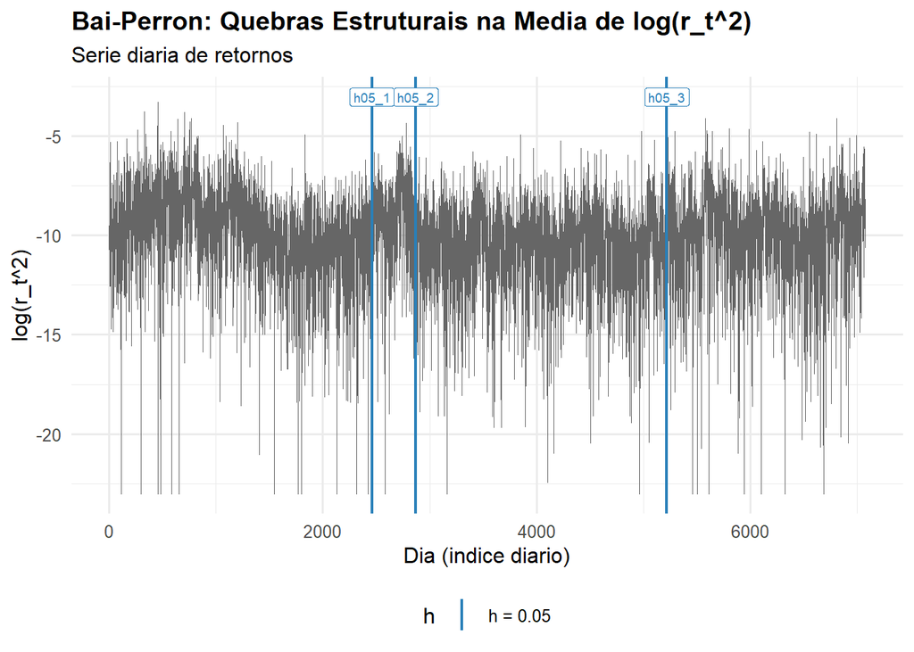

```r
# --- Grafico: log(r_t^2) com os breakpoints ---
bp_plot_df <- if (length(bp_daily_idx) > 0)
  data.frame(
    x     = bp_daily_idx,
    label = paste0("h05_", seq_along(bp_daily_idx)),
    h     = "h = 0.05"
  ) else data.frame()

color_h <- c("h = 0.05" = "#2980B9", "h = 0.10" = "#E67E22", "h = 0.01" = "#27AE60")
lty_h   <- c("h = 0.05" = "solid",   "h = 0.10" = "dashed",  "h = 0.01" = "dotted")

ggplot(data.frame(t = seq_len(n_daily), y = log_ret2),
       aes(x = t, y = y)) +
  geom_line(color = "grey40", linewidth = 0.3) +
  geom_vline(data = bp_plot_df,
             aes(xintercept = x, color = h, linetype = h),
             linewidth = 0.8) +
  geom_label(data = bp_plot_df,
             aes(x = x, y = max(log_ret2, na.rm = TRUE) * 0.92,
                 label = label, color = h),
             size = 2.5, show.legend = FALSE) +
  scale_color_manual(values = color_h) +
  scale_linetype_manual(values = lty_h) +
  labs(title    = "Bai-Perron: Quebras Estruturais na Media de log(r_t^2)",
       subtitle = "Serie diaria de retornos",
       x = "Dia (indice diario)", y = "log(r_t^2)",
       color = "h", linetype = "h") +
  theme_minimal(base_size = 12) +
  theme(plot.title = element_text(face = "bold"), legend.position = "bottom")
```

15/10/2007 Início da turbulência da crise financeira global Crescimento da crise do subprime nos EUA Aumento da volatilidade das ações de tecnologia, incluindo IBM Período associado ao começo da transição para a crise de 2008 03/06/2009 Instabilidade durante a recuperação pós-crise de 2008 Economia mundial ainda em recessão após a quebra do Lehman Brothers Dados fracos de emprego nos EUA 28/09/2018 Volatilidade causada por juros e guerra comercial Tensões da guerra comercial entre EUA e China Aumento das taxas de juros pelo Federal Reserve System

## Teste ARCH-LM: Clustering de Volatilidade nos Breakpoints

> **Teste ARCH-LM (Engle, 1982) — Clustering de Volatilidade**

> O Multiplicador de Lagrange de Engle testa se os quadrados dos residuos $\hat{\varepsilon}_t^2$ possuem autocorrelacao, indicando heterocedasticidade condicional (variancia nao constante ao longo do tempo).

> O modelo ARCH($q$) postula:
> $$\sigma_t^2 = \omega + \sum_{i=1}^{q} \alpha_i\,\varepsilon_{t-i}^2$$

> O teste LM regride $\hat{\varepsilon}_t^2$ em suas $q$ defasagens:
> $$LM = n \cdot R^2 \;\sim\; \chi^2(q)$$

> **Hipoteses:**
> - $H_0$: $\alpha_1 = \cdots = \alpha_q = 0$ — sem efeito ARCH (variancia constante)
> - $H_1$: pelo menos um $\alpha_i \neq 0$ — volatilidade depende do passado

> **Calibracao:** defasagens fixadas em $q = 5$ (5 dias de retornos diarios), capturando clustering de volatilidade de curto prazo. Janelas de `PRE_DAYS` e `POST_DAYS` dias antes e depois de cada breakpoint. Nivel de significancia $\alpha = 0.05$.

```r
run_arch_lm <- function(r, lag = 5) {
  r <- as.numeric(na.omit(r))
  if (length(r) < lag + 10) return(list(stat = NA_real_, pval = NA_real_))
  tryCatch({
    fit <- FinTS::ArchTest(r, lags = lag)
    list(stat = unname(fit$statistic), pval = fit$p.value)
  }, error = function(e) list(stat = NA_real_, pval = NA_real_))
}

# ---- Constroi linhas ARCH para um conjunto de breakpoints (escala diaria) ----
make_arch_rows <- function(didx_vec, prefix) {
  do.call(rbind, lapply(seq_along(didx_vec), function(k) {
    D      <- didx_vec[k]
    r_pre  <- ret_daily[safe_window_d(D - PRE_DAYS,  D - 1,           n_daily)]
    r_post <- ret_daily[safe_window_d(D + 1,          D + POST_DAYS,   n_daily)]
    a_pre  <- run_arch_lm(r_pre)
    a_post <- run_arch_lm(r_post)
    data.frame(
      h          = prefix,
      evento     = paste0(prefix, "_", k),
      daily_idx  = D,
      trade_date = as.character(dc_clean$trade_date[min(D, n_daily)]),
      LM_pre     = round(a_pre$stat,  4),
      p_pre      = round(a_pre$pval,  6),
      LM_post    = round(a_post$stat, 4),
      p_post     = round(a_post$pval, 6),
      ARCH_pre   = ifelse(!is.na(a_pre$pval)  & a_pre$pval  < 0.05, "Sim", "Nao"),
      ARCH_post  = ifelse(!is.na(a_post$pval) & a_post$pval < 0.05, "Sim", "Nao")
    )
  }))
}

arch_tbl <- bind_rows(
  make_arch_rows(bp_daily_idx,      "BP h=0.05"),
  #make_arch_rows(bp_daily_idx_h10,  "BP h=0.10"),
  #make_arch_rows(bp_daily_idx_h01,  "BP h=0.01")
) %>% arrange(h, daily_idx)

cat("=== Teste ARCH-LM (lags=5) — pre vs pos breakpoint (serie diaria) ===\n")
```

```
=== Teste ARCH-LM (lags=5) — pre vs pos breakpoint (serie diaria) ===
```

```r
cat("H0: sem efeito ARCH (variancia constante)  |  Rejeitar H0 se p < 0.05\n\n")
```

```
H0: sem efeito ARCH (variancia constante)  |  Rejeitar H0 se p < 0.05
```

```r
knitr::kable(arch_tbl,
             col.names = c("h","Evento","Idx diario","Data",
                           "LM (pre)","p (pre)","LM (pos)","p (pos)",
                           "ARCH pre?","ARCH pos?"),
             caption = "Teste ARCH-LM(5): clustering de volatilidade pre vs pos breakpoint — serie diaria")
```

Teste ARCH-LM(5): clustering de volatilidade pre vs pos breakpoint — serie diaria

|  | h | Evento | Idx diario | Data | LM (pre) | p (pre) | LM (pos) | p (pos) | ARCH pre? | ARCH pos? |
| --- | --- | --- | --- | --- | --- | --- | --- | --- | --- | --- |
| Chi-squared | BP h=0.05 | BP h=0.05_1 | 2460 | 2007-10-15 | 5.2679 | 0.384065 | 5.2828 | 0.382354 | Nao | Nao |
| Chi-squared1 | BP h=0.05 | BP h=0.05_2 | 2871 | 2009-06-03 | 7.3441 | 0.196283 | 12.2253 | 0.031828 | Nao | Sim |
| Chi-squared2 | BP h=0.05 | BP h=0.05_3 | 5219 | 2018-09-28 | 1.3627 | 0.928352 | 3.3289 | 0.649425 | Nao | Nao |

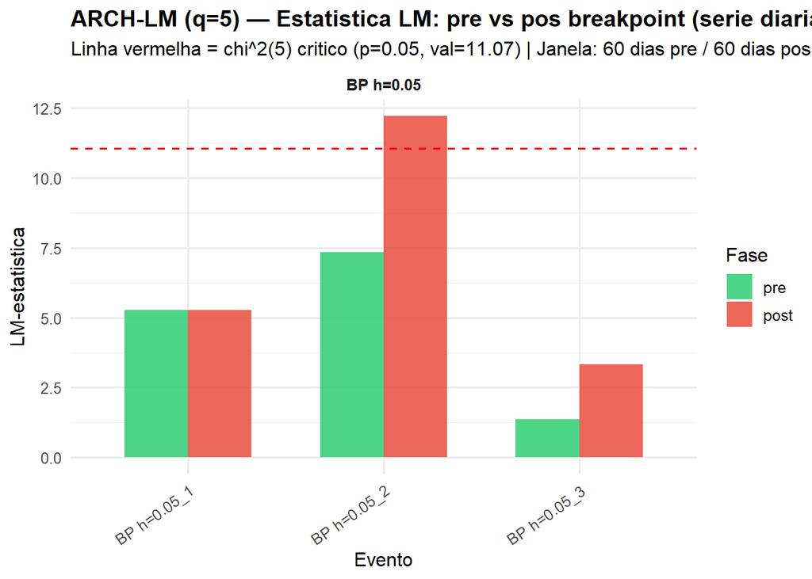

```r
# ---- Grafico: LM-stat pre vs pos por h ----
chi_crit <- qchisq(0.95, df = 5)

arch_long <- arch_tbl %>%
  select(h, evento, daily_idx, LM_pre, LM_post) %>%
  pivot_longer(cols = c(LM_pre, LM_post),
               names_to  = "fase",
               values_to = "LM_stat") %>%
  mutate(fase = ifelse(fase == "LM_pre", "pre", "post"),
         fase = factor(fase, levels = c("pre", "post")))

print(
  ggplot(arch_long %>% filter(!is.na(LM_stat)),
         aes(x = reorder(evento, daily_idx), y = LM_stat, fill = fase)) +
    geom_col(position = "dodge", width = 0.65, alpha = 0.85) +
    geom_hline(yintercept = chi_crit, linetype = "dashed",
               color = "red", linewidth = 0.7) +
    facet_wrap(~ h, scales = "free_x", ncol = 1) +
    scale_fill_manual(values = c(pre = "#2ECC71", post = "#E74C3C")) +
    labs(title    = "ARCH-LM (q=5) — Estatistica LM: pre vs pos breakpoint (serie diaria)",
         subtitle = paste0("Linha vermelha = chi^2(5) critico (p=0.05, val=",
                           round(chi_crit, 2), ") | Janela: ", PRE_DAYS, " dias pre / ", POST_DAYS, " dias pos"),
         x = "Evento", y = "LM-estatistica", fill = "Fase") +
    theme_minimal(base_size = 12) +
    theme(axis.text.x = element_text(angle = 35, hjust = 1),
          plot.title  = element_text(face = "bold"),
          strip.text  = element_text(face = "bold"))
)
```

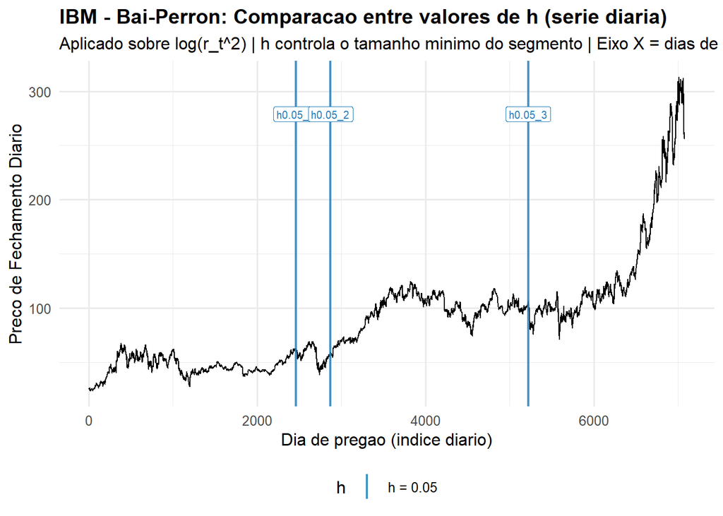

```r
price_daily_max <- max(dc_clean$close_last, na.rm = TRUE)

# ---- Monta data.frame com todos os breakpoints (escala diaria) ----
make_marks <- function(didx_vec, h_label, y_frac) {
  if (length(didx_vec) == 0) return(NULL)
  data.frame(
    x      = didx_vec,
    h      = h_label,
    label  = paste0(gsub("h = ", "h", h_label), "_", seq_along(didx_vec)),
    y_pos  = price_daily_max * y_frac,
    stringsAsFactors = FALSE
  )
}

all_marks <- bind_rows(
  make_marks(bp_daily_idx,     "h = 0.05", 0.89),
  #make_marks(bp_daily_idx_h10, "h = 0.10", 0.76),
  #make_marks(bp_daily_idx_h01, "h = 0.01", 0.63)
) %>%
  mutate(h = factor(h, levels = c("h = 0.05", "h = 0.10", "h = 0.01")))

color_h  <- c("h = 0.05" = "#2980B9", "h = 0.10" = "#E67E22", "h = 0.01" = "#27AE60")
lty_h    <- c("h = 0.05" = "solid",   "h = 0.10" = "dashed",  "h = 0.01" = "dotted")

print(
  ggplot(data.frame(index = seq_len(n_daily), price = dc_clean$close_last),
         aes(x = index, y = price)) +
    geom_line(color = "black", linewidth = 0.4) +
    geom_vline(data = all_marks,
               aes(xintercept = x, color = h, linetype = h),
               linewidth = 0.75, alpha = 0.85) +
    geom_label(data = all_marks,
               aes(x = x, y = y_pos, label = label, color = h),
               size = 2.6, show.legend = FALSE) +
    scale_color_manual(values = color_h) +
    scale_linetype_manual(values = lty_h) +
    labs(
      title    = "IBM - Bai-Perron: Comparacao entre valores de h (serie diaria)",
      subtitle = "Aplicado sobre log(r_t^2) | h controla o tamanho minimo do segmento | Eixo X = dias de pregao",
      x = "Dia de pregao (indice diario)", y = "Preco de Fechamento Diario",
      color = "h", linetype = "h"
    ) +
    theme_minimal(base_size = 12) +
    theme(plot.title = element_text(face = "bold"), legend.position = "bottom")
)
```

## Visualizacao: Janelamentos dos Breakpoints

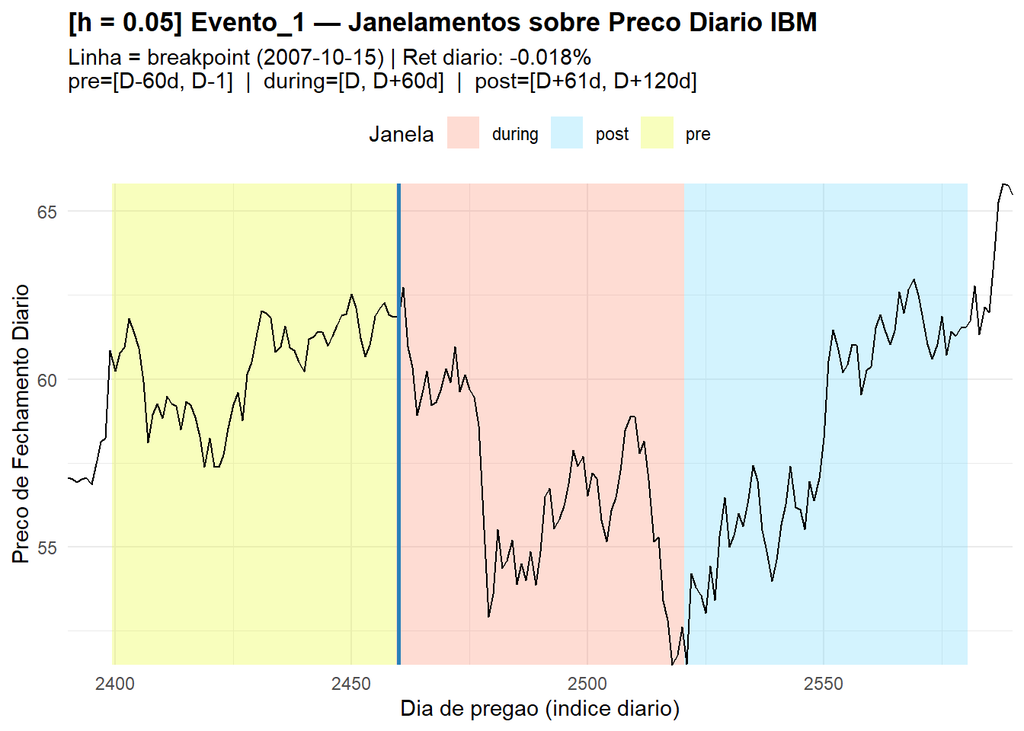

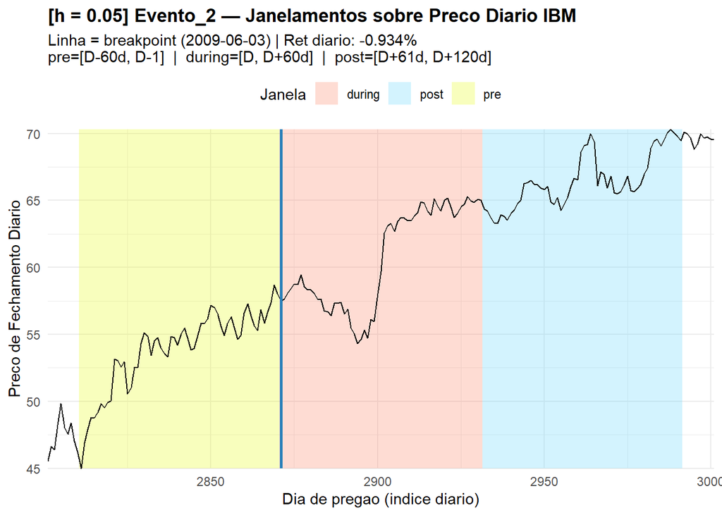

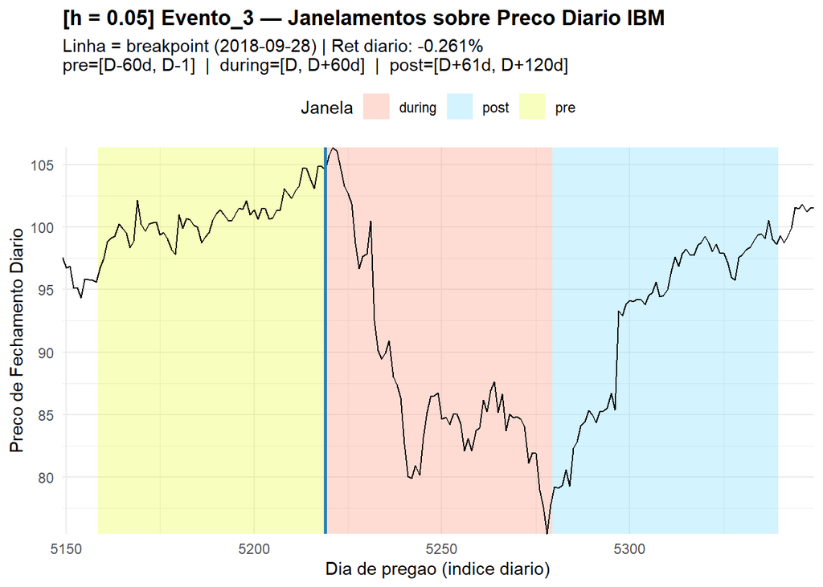

```r
fill_colors_seg <- c(pre = "#E8FA22", during = "#FC886D", post = "#6DD6FC")

# ---- Funcao auxiliar: plota janelas diarias para um conjunto de breakpoints ----
plot_windows_for_h <- function(didx_vec, h_label, line_color) {
  top5_vec <- head(didx_vec, 5)
  if (length(top5_vec) == 0) {
    cat(sprintf("[%s] Nenhum breakpoint disponivel.\n", h_label))
    return(invisible(NULL))
  }

  for (k in seq_along(top5_vec)) {
    D <- top5_vec[k]

    segs_df <- do.call(rbind, lapply(c("pre", "during", "post"), function(nm) {
      win <- switch(nm,
        pre    = safe_window_d(D - PRE_DAYS,            D - 1,              n_daily),
        during = safe_window_d(D,                        D + POST_DAYS,      n_daily),
        post   = safe_window_d(D + POST_DAYS + 1,        D + 2 * POST_DAYS,  n_daily)
      )
      if (is.null(win)) return(NULL)
      data.frame(janela = nm, xmin = win[1] - 0.5, xmax = tail(win, 1) + 0.5)
    }))

    zoom_s  <- max(1L,      D - PRE_DAYS  - 10L)
    zoom_e  <- min(n_daily, D + 2 * POST_DAYS + 10L)
    plot_df <- dc_clean[zoom_s:zoom_e, ] %>%
      mutate(index = zoom_s:zoom_e)

    crash_date <- dc_clean$trade_date[min(D, n_daily)]
    crash_ret  <- ret_daily[min(D, n_daily)]

    print(
      ggplot(plot_df, aes(x = index, y = close_last)) +
        geom_rect(data = segs_df,
                  aes(xmin = xmin, xmax = xmax, ymin = -Inf, ymax = Inf, fill = janela),
                  inherit.aes = FALSE, alpha = 0.30) +
        geom_line(color = "black", linewidth = 0.5) +
        geom_vline(xintercept = D, color = line_color,
                   linewidth = 0.9, linetype = "solid") +
        scale_fill_manual(name = "Janela", values = fill_colors_seg) +
        labs(
          title    = paste0("[", h_label, "] Evento_", k,
                            " — Janelamentos sobre Preco Diario IBM"),
          subtitle = paste0(
            "Linha = breakpoint (", format(crash_date, "%Y-%m-%d"),
            ") | Ret diario: ", round(crash_ret * 100, 3), "%",
            "\npre=[D-", PRE_DAYS, "d, D-1]  |  during=[D, D+", POST_DAYS,
            "d]  |  post=[D+", POST_DAYS + 1, "d, D+", 2 * POST_DAYS, "d]"
          ),
          x = "Dia de pregao (indice diario)", y = "Preco de Fechamento Diario"
        ) +
        theme_minimal(base_size = 11) +
        theme(plot.title = element_text(face = "bold"), legend.position = "top") +
        coord_cartesian(expand = FALSE)
    )
  }
}

# ---- Plota para cada valor de h ----
plot_windows_for_h(bp_daily_idx,     "h = 0.05", "#2980B9")
```

```r
#plot_windows_for_h(bp_daily_idx_h10, "h = 0.10", "#E67E22")
#plot_windows_for_h(bp_daily_idx_h01, "h = 0.01", "#27AE60")
```